# Building Models for Stratigraphic Paleobiology in R

## Stratigraphic Paleobiology

The fossil record is a joint expression of

- Stratigraphy
- Preservation
- Biology (ecology & evolution)

## Example: evolution in the time domain

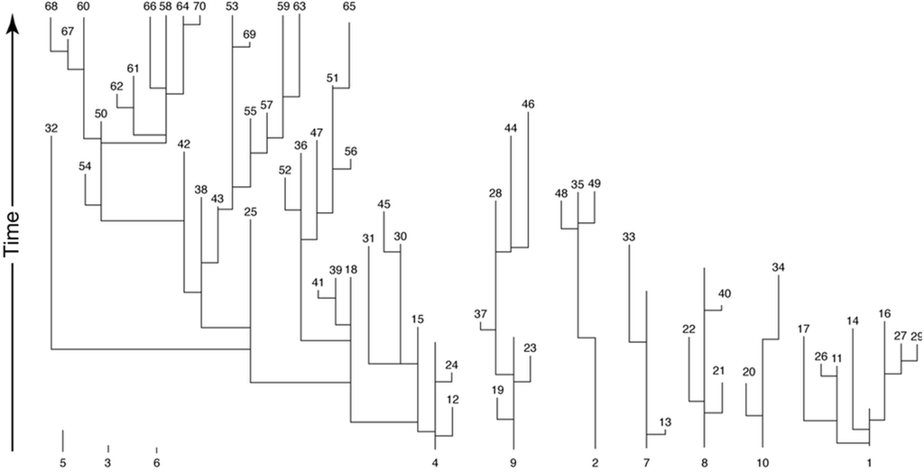

## Example: evolution in the stratigraphic domain

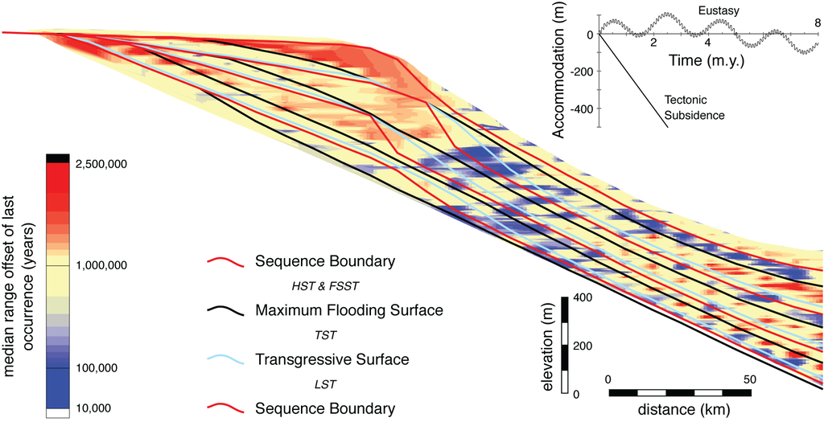

From Patzkowsky and Holland (2012)

## Aims

Combine models of stratigraphy with evolutionary biology and ecology into stratigraphic paleobiology modeling pipelines

**Focus:**

1. Age-depth models and incompleteness
2. Trait evolution
3. Fossil abundance, ecology, and last occurrences

## Example data

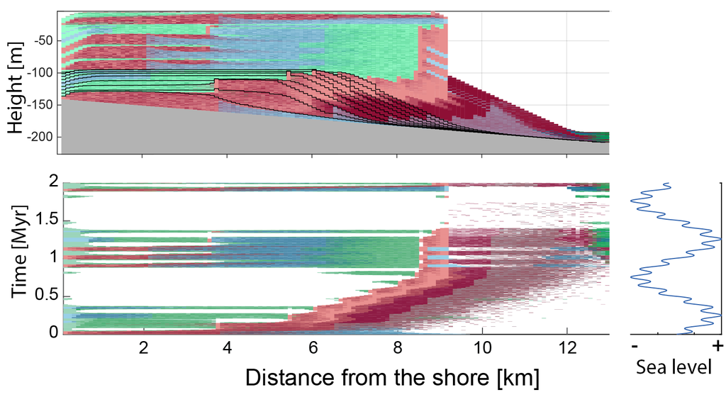

data simulated using CarboCAT (Burgess 2013, 2023), figure modified from Hohmann et al. (2024)

## Age-depth models (ADMs)

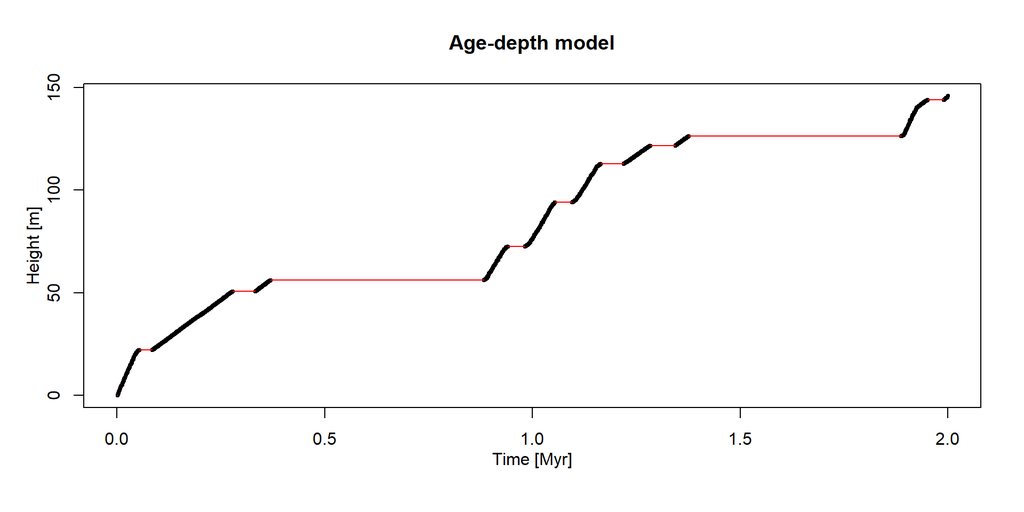

## Piping

```r
rnorm(500) |>                          # generate 500 normally distributed random numbers
  hist(main = "Normal distribution")   # plot histogram
```

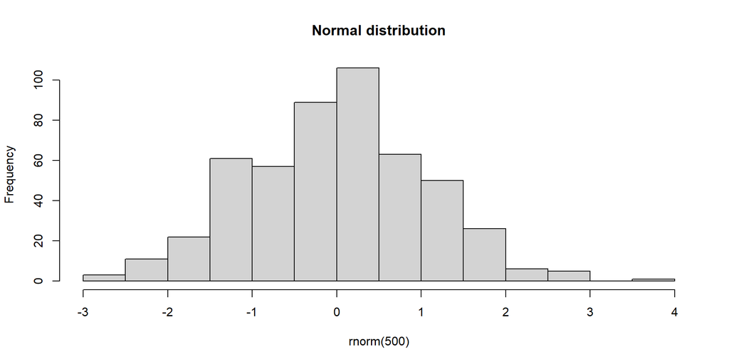

`|>` is the pipe operator  
Read the code like text!

## Piping example

```r
seq(from = 0, to = 1, by = 0.01) |>  # fix time steps of evaluation
  random_walk() |>                   # simulate random walk
  plot(type = "l",                   # plot results
       xlab = "Time",
       ylab = "Value",
       lwd = 2)
```

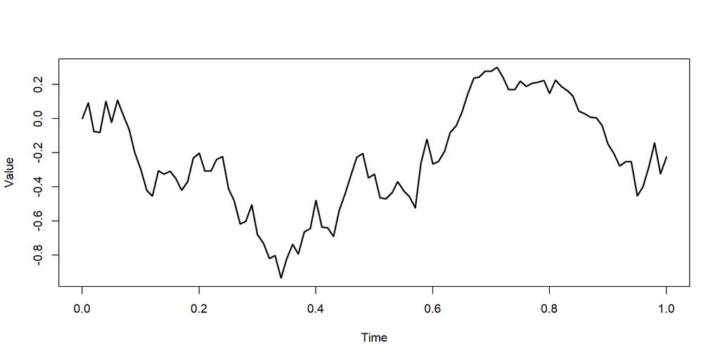

## Tasks ADMs and incompleteness (45 min)

1. Define age-depth models for different locations along the onshore-offshore gradient, and plot them.
   - How do they connect to the chronostratigraphic diagram and the sea level curve?
2. Examine how stratigraphic incompleteness and the number of hiatuses changes along the onshore-offshore gradient.
3. Generate histograms of hiatus durations at the different distances from shore.
   - Do you see any systematic changes?

## Results

## Break (15 min)

## Trait evolution

Traits are measurable characteristics of an organism  
How do traits evolve in a lineage?

## Modes of evolution

- **Stasis** - no net change
- **Random walk** - random accumulation of change
- **Ornstein-Uhlenbeck (OU) process** - convergence towards an optimum

## Question

- How do stratigraphic biases change our perception of the mode of evolution?

See Hohmann et al. (2024) for a detailed study

## Tasks trait evolution (45 min)

1. Plot the different modes of evolution in the time domain.
   - What is their internal variation due to randomness (i.e., how much do results differ if you plot them multiple times)?
   - What is the biological meaning of the model parameters?
2. Transform the different modes of evolution into the stratigraphic domain and plot them.
   - Which modes are most/least affected by stratigraphic biases?
   - Do you see any systematic changes?

## Results

## Break (15 min)

## Niche modeling and last occurrences

- Taxa track their preferred niche
- Environmental conditions at a place change with time

## Questions

- How does ecology change fossil abundance?
- How does stratigraphy influence extinction rate estimates?

## Tasks ecology and last occurrences (45 min)

### Ecology

1. Simulate an abundant taxon, and transform the fossil ages into the stratigraphic domain.
   - At which locations and stratigraphic heights do you observe peaks in fossil abundance?
   - With which stratigraphic effects are these peaks associated?
2. Define a niche for a taxon, and add the niche model to your pipeline.
   - How and why do your results change?
   - How could you misinterpret the results?

## Tasks ecology and last occurrences (45 min)

### Last occurrences

3. Simulate last occurrences based on the assumption of a constant rate of last occurrences and transform them into the stratigraphic domain.
   - Where do you observe clusters of last occurrences?
   - With what stratigraphic effects are these locations associated?
   - How would you misinterpret the results in the absence of stratigraphic information? Use your results to formulate a “stratigraphic null hypothesis” for clusters of last occurrences.

## Results

## Advanced usage

- Other forward models
- Other biological models (niches, trait evolution)
- Other data structures (phylogenetic trees)

Contributors welcome!

## References

Burgess, Peter. 2013. “CarboCAT: A Cellular Automata Model of Heterogeneous Carbonate Strata.” *Computers & Geosciences* 53: 129–40. https://doi.org/https://doi.org/10.1016/j.cageo.2011.08.026.

———. 2023. “CarboCATLite.” Zenodo. https://doi.org/10.5281/zenodo.8402578.

Hohmann, Niklas, Joël R. Koelewijn, Peter Burgess, and Emilia Jarochowska. 2024. “Identification of the Mode of Evolution in Incomplete Carbonate Successions.” *BMC Ecology and Evolution* 24 (1): 113. https://doi.org/10.1186/s12862-024-02287-2.

Patzkowsky, Mark E, and Steven M Holland. 2012. *Stratigraphic Paleobiology: Understanding the Distribution of Fossil Taxa in Time and Space*. University of Chicago Press.